# OS PROJETOS ESTRUTURANTES DE PERNAMBUCO: CIDADES DO INTERIOR DE PE

EDUARDA RIBEIRO FEITOSA, NICOLLE TASILA LOPES DE SOUZA , YLANE DARA MARQUES DIAS

2024-11-27

## Introdução

Pernambuco enfrenta desigualdades entre a capital, Recife, e o interior, e o governo busca reduzir essas disparidades com projetos estruturantes voltados para infraestrutura, serviços públicos e crescimento econômico. O plano estratégico Pernambuco 2035 foca no desenvolvimento sustentável a longo prazo, enquanto o PE Conectado melhora a comunicação em áreas rurais.

Projetos como a Transnordestina, expansão de energia no Sertão, o Polo de Confecção do Agreste e o Projeto de Irrigação do Rio São Francisco impulsionam a economia interiorana. Além disso, a modernização de aeroportos regionais, incentivos à irrigação e energia renovável integram o interior a mercados nacionais e internacionais.

Essas iniciativas fortalecem o turismo, a agricultura e promovem a sustentabilidade, melhorando a qualidade de vida e equilibrando o desenvolvimento regional.

## Pernambuco 2035:Plano Estratégico de Desenvolvimento de Longo Prazo

### Objetivos principais

- Desenvolvimento econômico sustentável
- Transformações de infraestrutura
- Melhoria da qualidade de vida
- Inovação e educação

### Impactos econômicos

- Diversificação econômica
- Geração de empregos de alta qualidade
- Atração de investimentos e parcerias
- Sustentabilidade e energia renovável

## PE Conectado: Inovação e Conectividade

- Melhoria da comunicação, especialmente em áreas rurais.
- Objetivo de modernizar e integrar a administração estadual e o campo, promovendo eficiência na gestão pública.

## A Transnordestina: Impactos na Logística e Competitividade Regional

#### Conexão Regional

- A Transnordestina ligará o interior do Nordeste aos portos de Suape e Recife, em Pernambuco.

#### Objetivos Principais

- Reduzir custos logísticos.
- Aumentar a competitividade de produtos agrícolas e minerais.
- Gerar novos empregos.

## Impactos Econômicos (IPEA, 2023)

- Facilitar o escoamento de grãos e frutas para mercados nacionais e internacionais.
- Estimular o comércio interregional.
- Impulsionar o desenvolvimento industrial em regiões remotas, com melhor transporte de insumos e produtos acabados.

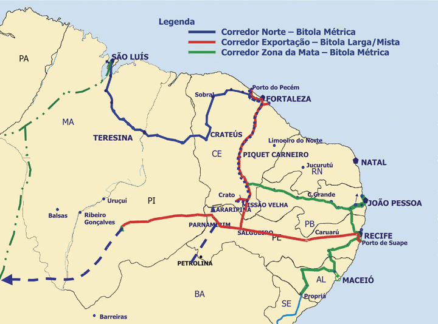

> - Extensão: Prevista para 1.753 km.
> - Trajeto: Conectará Eliseu Martins (PI) aos portos de Pecém (CE) e Suape (PE).
> - Importância: Estratégica para o desenvolvimento do Nordeste, facilitando o transporte de grãos, minério e combustíveis.

## O Projeto de Irrigação do Rio São Francisco: Transformando o Sertão

#### Descrição do Projeto

- Sistema de adutoras e canais (Canal do Sertão) que leva água do Rio São Francisco para áreas áridas do Sertão pernambucano.
- Objetivo de transformar o Sertão em uma região produtiva para grãos, frutas e hortaliças.

#### Impactos Econômicos e Sociais (Codevasf, 2023)

- Geração de empregos e melhoria da segurança alimentar.
- Estímulo à adoção de técnicas agrícolas modernas.
- Aumento da produtividade e diversificação da produção.
- Fortalecimento da agricultura familiar e promoção do desenvolvimento sustentável.

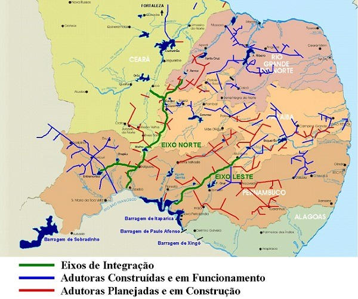

## Expansão da Energia Elétrica: Potencializando o Desenvolvimento do Sertão

#### Descrição do Projeto:

- Expansão da rede elétrica no Sertão pernambucano para inclusão econômica e social.
- Energia como suporte essencial para agricultura, indústria, comércio e qualidade de vida.

#### Estratégias Sustentáveis (SIRH, 2024):

- Adoção de energia solar aproveitando a alta incidência solar na região.
- Geração de energia própria em propriedades rurais, reduzindo custos operacionais.

#### Impactos Econômicos e Sociais:

- Ampliação do acesso à energia elétrica em áreas remotas.
- Estímulo à instalação de indústrias e empreendimentos no interior.
- Criação de empregos e fortalecimento da competitividade estadual.

## Modernização dos Aeroportos Regionais: Facilitando a Conexão do Interior

#### Descrição do Projeto:

- Modernização de aeroportos regionais, como o Aeroporto de Serra Talhada, no Sertão de Pernambuco.
- Melhorias na infraestrutura aeroportuária para transporte de passageiros e mercadorias.

#### Principais Reformas e Benefícios:

- Aumento da capacidade de operação e frequência de voos.
- Conexão mais eficiente do interior com Recife e outros estados.

#### Impactos Econômicos e Sociais (SIRH, 2024):

- Impulso ao comércio local e ao turismo.
- Facilidade no acesso às atrações naturais e culturais da região.
- Escoamento mais eficiente de produtos agrícolas e artesanais para outros mercados.
> - Aeroporto de Recife
> - Aeroporto de Petrolina
> - Aeroporto de Caruaru
> - Aeroporto de Serra Talhada
> - Aeroporto de Garanhuns
> - Aeroporto de Araripina
> - Aeroporto de Fernando de Noronha
> - Aeroporto de Salgueiro

## O Polo de Confecção do Agreste: Desenvolvimento Econômico e Sustentabilidade

#### Descrição do Polo:

- Um dos maiores centros industriais de Pernambuco, com destaque para Caruaru, Toritama e Santa Cruz do Capibaribe.
- Produção de roupas e acessórios, consolidando o Agreste como um dos maiores polos de confecção do Brasil.

#### Fatores de Crescimento:

- Melhoria da infraestrutura logística.
- Acesso facilitado a mercados internacionais.
- Investimentos em tecnologia e logística para aumentar a competitividade global.

#### Impactos Econômicos e Sociais (FUNDAJ, 2023)

- Geração de milhares de empregos diretos e indiretos.
- Fomento ao empreendedorismo e à inovação.
- Capacitação profissional e formalização de empresas.
- Acesso a crédito para pequenos e médios negócios.

#### Sustentabilidade e Inovação:

- Uso de tecidos ecológicos e processos de produção eficientes.
- Incentivos governamentais para práticas sustentáveis e descarbonização do setor.
- Melhoria das condições de trabalho na região.

[figure not shown]

## Considerações finais

Os projetos estruturantes em Pernambuco têm sido cruciais para transformar o interior do estado, promovendo desenvolvimento econômico e social em áreas historicamente marginalizadas. Iniciativas como a Transnordestina, o Projeto de Irrigação do Rio São Francisco e a expansão da energia elétrica têm integrado o Sertão e o Agreste ao restante do país, fortalecendo a produção agrícola, gerando empregos e aumentando a competitividade regional. Apesar dos avanços, desafios como a qualificação profissional, a inclusão digital e a sustentabilidade ainda precisam ser enfrentados para assegurar que o progresso beneficie toda a população. Com perspectivas positivas, o sucesso desses projetos dependerá de políticas públicas que priorizem capacitação, inovação e desenvolvimento sustentável, colocando Pernambuco em posição de destaque como modelo de integração regional e crescimento equilibrado.